# Partial Least Squares Regression (PLSR) with Boruta Feature Selection for Quantifying Coffee Adulteration: Spectral Preprocessing Using MSC, Savitzky-Golay, and First Derivative

Author

Derick Malavi

## Introduction

Coffee adulteration, such as blending premium Arabica with lower-cost Robusta, undermines quality and authenticity, posing significant challenges for consumers, producers, and regulators. High-dimensional spectroscopic data provides valuable insights for detecting such fraud, but the large number of variables necessitates effective feature selection techniques to isolate the most relevant wavelengths.

This study employs the Boruta algorithm, a robust feature selection method that identifies all relevant variables by iteratively comparing the importance of original features with randomized counterparts using a Random Forest framework. Unlike traditional methods, Boruta not only ensures the inclusion of critical spectral features but also avoids selecting irrelevant or redundant variables, which is essential for improving model interpretability and performance.

```r
# Load libraries
warning = FALSE
  suppressWarnings(suppressMessages({
  library(caret)
  library(GA)
  library(viridis)
  library(Boruta)
  library(ggplot2)
  library(dplyr)
  library(readxl)
  library(readr)
  library(pls)
  library(janitor)
  library(class)
  library(MLmetrics)
  library(MLeval)
  library(themis)
  library(ROSE)
  library(parallel)
  library(doParallel)
  library(foreach)
  library(pheatmap)
  library(mdatools)
  library(nnet)
  library(DMwR)
  library(e1071)
  library(knitr)
  library(pROC)
  library(gridExtra)
  library(FactoMineR)
  library(doSNOW)
  library(MASS)
  library(factoextra)
  library(kernlab)}))
```

## Prepare Data

```r
# Load data: msc_sg_1d spectra

hsi_msc_sg_1d <- read.csv("coffee_ground_msc_sg_1d.csv")

# Ensure we have the same number of dimensions and the range of our columns/covariates
dim(hsi_msc_sg_1d)
```

```
[1] 1469  229
```

```r
# Check a few column names
col_check <- colnames(hsi_msc_sg_1d[,c(1:6)])
col_check
```

```
[1] "sample_id"     "binary_class"  "three_class"   "adult_percent"
[5] "cal_val"       "X935.609985"
```

```r
# our response variable (adulteration percentage) is column 4
# The spectral values start from column # 6 -------> 229

# Convert the adulteration percentage to numeric for compatibility with ML
hsi_msc_sg_1d$adult_percent <- as.numeric(hsi_msc_sg_1d$adult_percent)
```

## Get the X and y variables

```r
X <- hsi_msc_sg_1d[,c(6:229)]
y <- hsi_msc_sg_1d[,4]

class(y) #Ensure y (target variable) is a numeric for regression
```

```
[1] "numeric"
```

## Visualize X

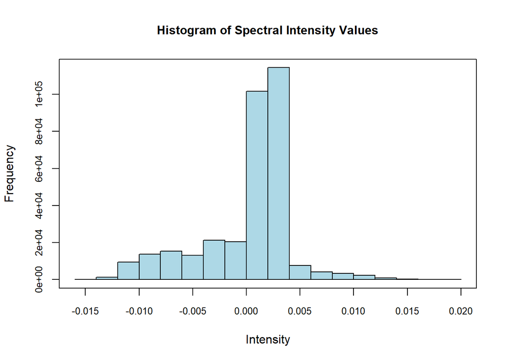

```r
hist(as.matrix(X), col = 'lightblue', cex.main = 1.0, cex.axis = 0.8,cex.lab = 1.0,
     main = 'Histogram of Spectral Intensity Values', xlab = 'Intensity'); box()
```

## Split the Data (Train_Test Split)

- We want to select features based on training data only to avoid any data leakage that could inflate model performance and make the model less generalizable to unseen data.

```r
# Subset samples for cross-validation and external validation (70/30)
# Record 1 under cal_val variable is for calibration while 2 will be for testing the model

sample<-hsi_msc_sg_1d$cal_val == 1

# Split to train and test sets
X_train <- X[sample,]
X_test <- X[!sample,]
y_train <-y[sample]
y_test <- y[!sample]

# Check length of the subsets for training and validation
dim(X_train)
```

```
[1] 1055  224
```

```r
dim(X_test)
```

```
[1] 414 224
```

```r
length(y_train)
```

```
[1] 1055
```

```r
length(y_test)
```

```
[1] 414
```

```r
# Merge the test and train data
train_data <- data.frame(X_train, y_train)
test_data <- data.frame(X_test, y_test)
```

## Run Boruta Algorithm for Optimum Wavelength Selection

```r
  # Set seed for reproducibility
  set.seed(123)

  # Set the dataset name dynamically
  dataset_name <- "msc_sg_1d"

  # Define paths for the execution flag and Boruta result
  flag_file <- paste0("boruta_executed_flag_", dataset_name, ".RData")
  result_file <- paste0("boruta_result_", dataset_name, ".RData")

  # Register cluster for caret to train the models in parallel
  cl <- makeCluster(6, type = "SOCK")
  suppressWarnings(suppressMessages(registerDoSNOW(cl)))

if (!file.exists(result_file)) {
  message(paste("Starting Boruta execution for dataset:", dataset_name))

  # Start the timer
  start_time <- Sys.time()

  # Run Boruta on the train data set
  boruta_result <- Boruta(formula = y_train ~ .,
                        data = train_data,
                        doTrace = 2,
                        maxRuns = 100)

  # Stop the cluster
  stopCluster(cl)

  # Register end time
  end_time <- Sys.time()
  print(paste('Time to run the Boruta model:', end_time - start_time))

  # Save Boruta results and execution flag
  boruta_executed <- TRUE
  save(boruta_executed, file = flag_file)
  save(boruta_result, file = result_file)


  message(paste("Boruta execution completed for dataset:", dataset_name, "and results saved."))

} else {
  # Load previously saved results
  message(paste("Result file found. Loading saved Boruta results for dataset:", dataset_name))
  load(result_file)
  load(flag_file)
  message(paste("Boruta already executed for dataset:", dataset_name))
}
```

```
Result file found. Loading saved Boruta results for dataset: msc_sg_1d
```

```
Boruta already executed for dataset: msc_sg_1d
```

```r
# Print Boruta summary
print(boruta_result)
```

```
Boruta performed 99 iterations in 7.956121 mins.
 199 attributes confirmed important: X1001.369995, X1004.830017,
X1008.299988, X1011.77002, X1015.23999 and 194 more;
 No attributes deemed unimportant.
 25 tentative attributes left: X1036.060059, X1039.530029, X1043,
X1046.47998, X1049.949951 and 20 more;
```

```r
# Get selected features
final_features <- getSelectedAttributes(boruta_result, withTentative = FALSE)
final_features
```

```
  [1] "X959.809998"  "X963.27002"   "X966.72998"   "X970.190002"  "X973.650024"
  [6] "X977.109985"  "X980.580017"  "X984.039978"  "X987.51001"   "X990.969971"
 [11] "X994.429993"  "X997.900024"  "X1001.369995" "X1004.830017" "X1008.299988"
 [16] "X1011.77002"  "X1015.23999"  "X1018.710022" "X1022.179993" "X1025.650024"
 [21] "X1029.119995" "X1032.589966" "X1095.170044" "X1098.650024" "X1102.130005"
 [26] "X1105.609985" "X1109.099976" "X1112.579956" "X1116.069946" "X1119.550049"
 [31] "X1123.040039" "X1126.52002"  "X1130.01001"  "X1133.5"      "X1136.98999"
 [36] "X1140.469971" "X1143.959961" "X1147.449951" "X1150.939941" "X1154.430054"
 [41] "X1157.930054" "X1161.420044" "X1164.910034" "X1168.400024" "X1171.900024"
 [46] "X1175.390015" "X1178.890015" "X1182.380005" "X1185.880005" "X1189.369995"
 [51] "X1192.869995" "X1196.369995" "X1199.869995" "X1203.369995" "X1206.869995"
 [56] "X1210.369995" "X1213.869995" "X1217.369995" "X1220.869995" "X1224.369995"
 [61] "X1227.869995" "X1231.380005" "X1234.880005" "X1238.390015" "X1241.890015"
 [66] "X1245.400024" "X1248.900024" "X1252.410034" "X1255.920044" "X1259.420044"
 [71] "X1262.930054" "X1266.439941" "X1269.949951" "X1273.459961" "X1276.969971"
```

[output cut: 25 more lines]

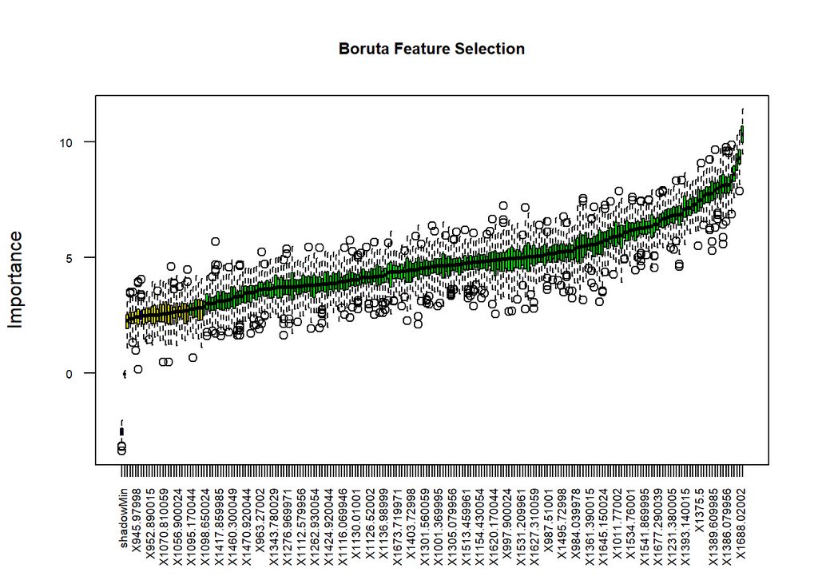

```r
# Plot Boruta results
plot(boruta_result, xlab = "", las = 2,
     cex.main = 0.8, cex.axis = 0.6,
     main = paste("Boruta Feature Selection"))
```

```r
print(paste('The number of selected variables are', length(final_features)))
```

```
[1] "The number of selected variables are 199"
```

## Create a Data frame with the Selected Features

```r
# Subset the training and test data using the selected features
X_train_selected <- X_train[, final_features]
X_test_selected <- X_test[, final_features]

# Keep y_train and y_test as-is
y_train_selected <- y_train
y_test_selected <- y_test


#Merge data_frame
train_merged <- cbind(X_train_selected, y_train = y_train_selected)
test_merged <- cbind(X_test_selected, y_test = y_test_selected)

dim(train_merged)
```

```
[1] 1055  200
```

```r
dim(test_merged)
```

```
[1] 414 200
```

## Check correlations by HeatMaps

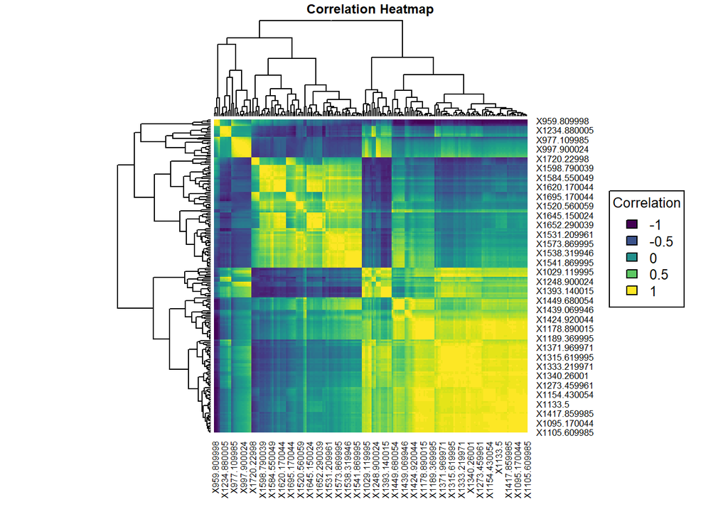

```r
n_features <- length(final_features)

#Calculate correlations
corr <- cor(train_merged[, -(n_features+1)])

# Create a heat map
par(cex.main = 0.6)
heatmap(corr, symm = TRUE,
        col = viridis(50),
        main = "Correlation Heatmap")

# Add legend

legend("right",
       legend = seq(-1, 1, by = 0.5),  # Correlation range
       fill = viridis(5),
       title = "Correlation", cex = 0.8)
```

## Train Models

- We will train models based on the reduced number of features.

```r
# Set random seed for reproducibility
set.seed (123)

# Set up the training control(10 folds 10 times cross_validation)
control <- trainControl(method = "repeatedcv", number = 10, repeats = 10,
                        savePredictions = "final",
                        summaryFunction = defaultSummary,
                        selectionFunction = 'best', allowParallel = TRUE)

# We used oneSE for classification. For regression, we will use 'best': a model that minimizes RMSECV
```

```r
#Set the metric as accuracy
metric<-"RMSE"
```

```r
# Hyperparameter Tuning
# We will use tuneLength to automatically determine the optimal number of PLS components
```

```r
set.seed(123)
#Register cluster for caret to train the models in parallel
cl<-makeCluster(6,type = "SOCK")
suppressWarnings(suppressMessages(
  registerDoSNOW(cl)))

# Start_time
start_time<-Sys.time()

#Train the model using cross-validation (10 folds, 10 times)
fit_pls_msc_sg_1d<-train(y = train_merged[,(n_features+1)],
                         x = train_merged[,-(n_features+1)],
                         method = 'pls', tuneLength = 60,
                         trControl = control,
                         metric = metric)
#End_time
end_time<-Sys.time()

model_training_time<-end_time-start_time

stopCluster(cl) # Stop the parallel run cluster

print(model_training_time)
```

```
Time difference of 15.22729 secs
```

```r
# Display regression results
print(fit_pls_msc_sg_1d)
```

```
Partial Least Squares

1055 samples
 199 predictor

No pre-processing
Resampling: Cross-Validated (10 fold, repeated 10 times)
Summary of sample sizes: 949, 949, 949, 948, 949, 950, ...
Resampling results across tuning parameters:

  ncomp  RMSE       Rsquared   MAE
   1     18.774583  0.5762489  15.183763
   2     17.043068  0.6504492  13.250199
   3     12.837877  0.8022997  10.170004
   4     12.162885  0.8227606   9.637958
```

[output cut: 59 more lines]

## Save the models for future use

```r
saveRDS(fit_pls_msc_sg_1d, "fit_pls_msc_sg_1d.rds")
```

## Plot the cross-validation results —–> Model Selection

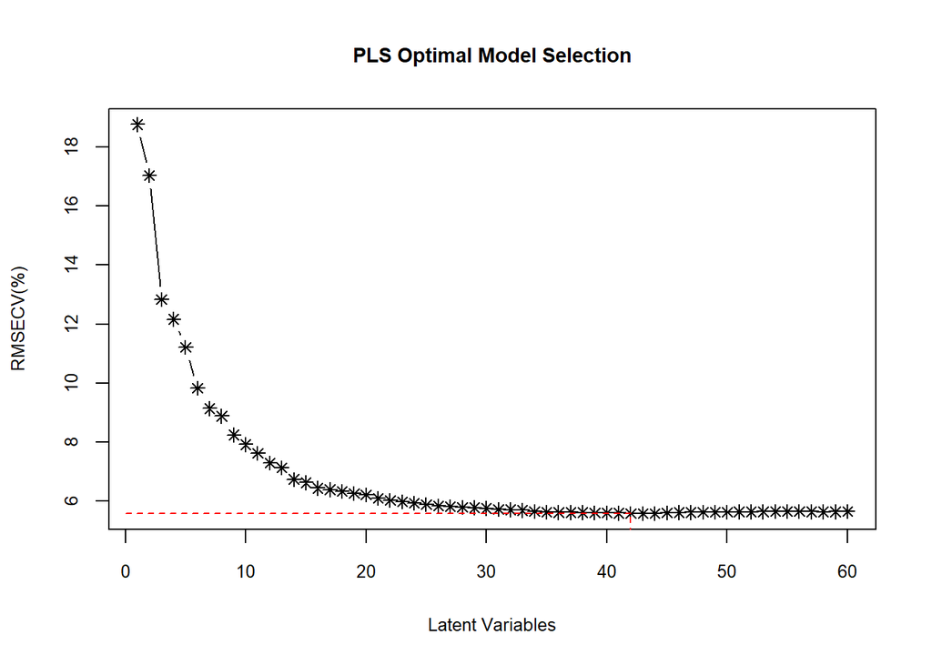

```r
# Imbalanced Data
pls_data <- fit_pls_msc_sg_1d$results
best_Lvs = fit_pls_msc_sg_1d$bestTune$ncomp
y_RMSE = pls_data$RMSE[pls_data$ncomp == best_Lvs]
plot(pls_data$ncomp,pls_data$RMSE, type = "b",col = "black",pch = 8,cex.axis = 0.8,
     xlab = "Latent Variables", ylab = "RMSECV(%)",cex.lab = 0.9,
     main = 'PLS Optimal Model Selection',
     cex.main = 0.9,
     cex.lab = 0.8)
# Add line from x-axis to the specific point
segments(x0 = best_Lvs, y0 = 0, x1 = best_Lvs, y1 = y_RMSE, col = "red", lty = 2)

# Add line from y-axis to the specific point
segments(x0 = 0, y0 = y_RMSE, x1 = best_Lvs, y1 = y_RMSE, col = "red", lty = 2)
```

## Display the cross-validation results

```r
print(paste('The optimal parameters for training the pls model is',
            fit_pls_msc_sg_1d$bestTune$ncomp, 'components'))
```

```
[1] "The optimal parameters for training the pls model is 42 components"
```

## Display CV Results in Tables

```r
kable(fit_pls_msc_sg_1d$results)
```

| ncomp | RMSE | Rsquared | MAE | RMSESD | RsquaredSD | MAESD |
| --- | --- | --- | --- | --- | --- | --- |
| 1 | 18.774583 | 0.5762489 | 15.183763 | 1.1055442 | 0.0457568 | 0.9121891 |
| 2 | 17.043068 | 0.6504492 | 13.250199 | 1.5404859 | 0.0573991 | 0.8140952 |
| 3 | 12.837877 | 0.8022997 | 10.170004 | 1.1047745 | 0.0318163 | 0.7137378 |
| 4 | 12.162885 | 0.8227606 | 9.637958 | 0.8630086 | 0.0233717 | 0.6828728 |
| 5 | 11.210100 | 0.8491772 | 8.760179 | 0.9532778 | 0.0242930 | 0.6562845 |
| 6 | 9.827179 | 0.8844994 | 7.749931 | 0.7197181 | 0.0160686 | 0.5779104 |
| 7 | 9.134234 | 0.9006124 | 7.167695 | 0.6384633 | 0.0129984 | 0.4889308 |
| 8 | 8.874564 | 0.9061594 | 6.990214 | 0.6054939 | 0.0121750 | 0.4726242 |
| 9 | 8.235548 | 0.9193253 | 6.535853 | 0.5520568 | 0.0100884 | 0.4546445 |
| 10 | 7.909791 | 0.9255011 | 6.310852 | 0.5302611 | 0.0091840 | 0.4519794 |
| 11 | 7.611396 | 0.9310373 | 6.052494 | 0.4996383 | 0.0083743 | 0.4240253 |
| 12 | 7.280941 | 0.9368477 | 5.794561 | 0.4904241 | 0.0079664 | 0.4134345 |
| 13 | 7.125787 | 0.9395085 | 5.709968 | 0.5141859 | 0.0082303 | 0.4137454 |
| 14 | 6.729374 | 0.9460950 | 5.351666 | 0.5026025 | 0.0077122 | 0.3898768 |
| 15 | 6.617479 | 0.9478714 | 5.274697 | 0.4626616 | 0.0069005 | 0.3748477 |
| 16 | 6.431232 | 0.9507552 | 5.121768 | 0.4103567 | 0.0063037 | 0.3449465 |
| 17 | 6.380198 | 0.9515461 | 5.052617 | 0.3984680 | 0.0059781 | 0.3245090 |
| 18 | 6.327318 | 0.9523368 | 4.990788 | 0.3893590 | 0.0057755 | 0.3225389 |
| 19 | 6.253149 | 0.9534393 | 4.928457 | 0.3936046 | 0.0058429 | 0.3268579 |
| 20 | 6.204240 | 0.9541199 | 4.906361 | 0.4024830 | 0.0059934 | 0.3332841 |
| 21 | 6.084154 | 0.9559026 | 4.814715 | 0.4227358 | 0.0060669 | 0.3609510 |
| 22 | 6.011624 | 0.9570111 | 4.737539 | 0.3995015 | 0.0057618 | 0.3427737 |
| 23 | 5.962554 | 0.9577292 | 4.683223 | 0.3874545 | 0.0056042 | 0.3345856 |
| 24 | 5.918096 | 0.9583466 | 4.658784 | 0.3862603 | 0.0055520 | 0.3304470 |
| 25 | 5.881312 | 0.9589095 | 4.658398 | 0.3878609 | 0.0055057 | 0.3295735 |
| 26 | 5.833450 | 0.9595751 | 4.631387 | 0.3771045 | 0.0053895 | 0.3326296 |
| 27 | 5.808658 | 0.9599260 | 4.611078 | 0.3836183 | 0.0054433 | 0.3323737 |
| 28 | 5.787407 | 0.9602120 | 4.566617 | 0.3737010 | 0.0051720 | 0.3156092 |
| 29 | 5.765525 | 0.9605266 | 4.557377 | 0.3695300 | 0.0050900 | 0.3124139 |
| 30 | 5.744607 | 0.9608511 | 4.559312 | 0.3531423 | 0.0048733 | 0.3005482 |
| 31 | 5.708115 | 0.9613573 | 4.508385 | 0.3720237 | 0.0051035 | 0.3162530 |
| 32 | 5.697616 | 0.9614959 | 4.506728 | 0.3634193 | 0.0050472 | 0.3046076 |
| 33 | 5.677365 | 0.9617818 | 4.500724 | 0.3605403 | 0.0049764 | 0.2924475 |
| 34 | 5.638701 | 0.9622932 | 4.489264 | 0.3582378 | 0.0048741 | 0.2864650 |
| 35 | 5.609958 | 0.9626725 | 4.457325 | 0.3563324 | 0.0047649 | 0.2808339 |
| 36 | 5.607926 | 0.9627168 | 4.453155 | 0.3526884 | 0.0046596 | 0.2803324 |
| 37 | 5.606356 | 0.9627255 | 4.470834 | 0.3423937 | 0.0045647 | 0.2739242 |
| 38 | 5.602818 | 0.9627934 | 4.473376 | 0.3444618 | 0.0045787 | 0.2808395 |
| 39 | 5.592405 | 0.9629267 | 4.468699 | 0.3468971 | 0.0045974 | 0.2829948 |
| 40 | 5.597099 | 0.9628720 | 4.462699 | 0.3449339 | 0.0045626 | 0.2816745 |
| 41 | 5.584274 | 0.9630345 | 4.455749 | 0.3378092 | 0.0045183 | 0.2762460 |
| 42 | 5.565339 | 0.9632921 | 4.443312 | 0.3345050 | 0.0044971 | 0.2701729 |
| 43 | 5.568201 | 0.9632474 | 4.448932 | 0.3284815 | 0.0044299 | 0.2666472 |
| 44 | 5.574116 | 0.9631613 | 4.453115 | 0.3218418 | 0.0043985 | 0.2624333 |
| 45 | 5.590753 | 0.9629458 | 4.465695 | 0.3233277 | 0.0044426 | 0.2656461 |
| 46 | 5.604693 | 0.9627703 | 4.483639 | 0.3162727 | 0.0043302 | 0.2613118 |
| 47 | 5.607554 | 0.9627420 | 4.483083 | 0.3123872 | 0.0042764 | 0.2539038 |
| 48 | 5.610579 | 0.9627028 | 4.487175 | 0.3119311 | 0.0043218 | 0.2493941 |
| 49 | 5.612630 | 0.9626719 | 4.493478 | 0.3168182 | 0.0044143 | 0.2514333 |
| 50 | 5.622668 | 0.9625592 | 4.499912 | 0.3158295 | 0.0044198 | 0.2539110 |
| 51 | 5.627336 | 0.9624970 | 4.503307 | 0.3132806 | 0.0044095 | 0.2470241 |
| 52 | 5.624417 | 0.9625447 | 4.501694 | 0.3134749 | 0.0044579 | 0.2493330 |
| 53 | 5.629410 | 0.9624831 | 4.509440 | 0.3140543 | 0.0044395 | 0.2513996 |
| 54 | 5.634432 | 0.9624159 | 4.516610 | 0.3137505 | 0.0044356 | 0.2527355 |
| 55 | 5.638204 | 0.9623719 | 4.521320 | 0.3154946 | 0.0044486 | 0.2543621 |
| 56 | 5.634352 | 0.9624209 | 4.518665 | 0.3144988 | 0.0044535 | 0.2529635 |
| 57 | 5.630847 | 0.9624655 | 4.515542 | 0.3144984 | 0.0044611 | 0.2510674 |
| 58 | 5.628200 | 0.9625090 | 4.515630 | 0.3124796 | 0.0044470 | 0.2499585 |
| 59 | 5.630674 | 0.9624800 | 4.518113 | 0.3102252 | 0.0044286 | 0.2491290 |
| 60 | 5.634335 | 0.9624344 | 4.519445 | 0.3138586 | 0.0044693 | 0.2509977 |

```r
# Select row for the optimal model
opt_row <- fit_pls_msc_sg_1d$results %>%
  filter(ncomp==fit_pls_msc_sg_1d$bestTune$ncomp)

kable(opt_row)
```

| ncomp | RMSE | Rsquared | MAE | RMSESD | RsquaredSD | MAESD |
| --- | --- | --- | --- | --- | --- | --- |
| 42 | 5.565339 | 0.9632921 | 4.443312 | 0.334505 | 0.0044971 | 0.2701729 |

## Test the model performance on test data

```r
#Predict on the test set
observed <- test_merged$y_test
predictions <- predict(fit_pls_msc_sg_1d,newdata=test_merged)

# Generate predictions
results <- postResample(predictions, observed)

print(results)
```

```
     RMSE  Rsquared       MAE
8.4629466 0.9213765 6.8702697
```

```r
RMSEP = results[[1]]
R2 = results[[2]]
MAE = results[[3]]

cat('The RMSEP for the model on external validation is:', RMSEP,'\n')
```

```
The RMSEP for the model on external validation is: 8.462947
```

```r
cat('The R Squared value for the model is:', R2,'\n')
```

```
The R Squared value for the model is: 0.9213765
```

```r
# Calculate Residual Predictive Deviation to check model performance

RPD = sd(observed)/RMSEP

print(paste('The RPD values for the model is', round(RPD,2)))
```

```
[1] "The RPD values for the model is 3.44"
```

## Visualizations

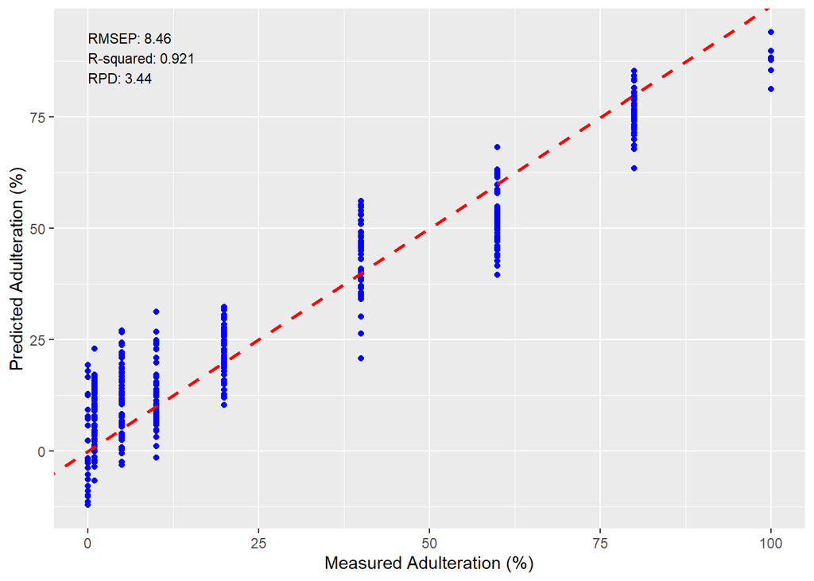

```r
# predicted vs observed line and scatter
# Create a data frame
results_df <- data.frame(observed=observed, predictions=predictions)

results_df %>%
  ggplot(aes(x = observed, y = predictions)) +
  geom_point(color = "blue") +
  geom_abline(slope = 1, intercept = 0, color = "red",
              linetype = "dashed", linewidth = 1) +
  labs( x = "Measured Adulteration (%)",
    y = "Predicted Adulteration (%)") +
  annotate("text",
    x = min(observed), y = max(predictions),
    label = paste("RMSEP:", round(RMSEP, 2),
      "\nR-squared:", round(R2, 3),
      "\nRPD:", round(RPD, 2)),
    hjust = 0, vjust = 1, size = 3, color = "black") +
  theme(
    axis.title = element_text(color = "black", size = 10),
    axis.text = element_text(color = "black"))+
  theme_gray()
```

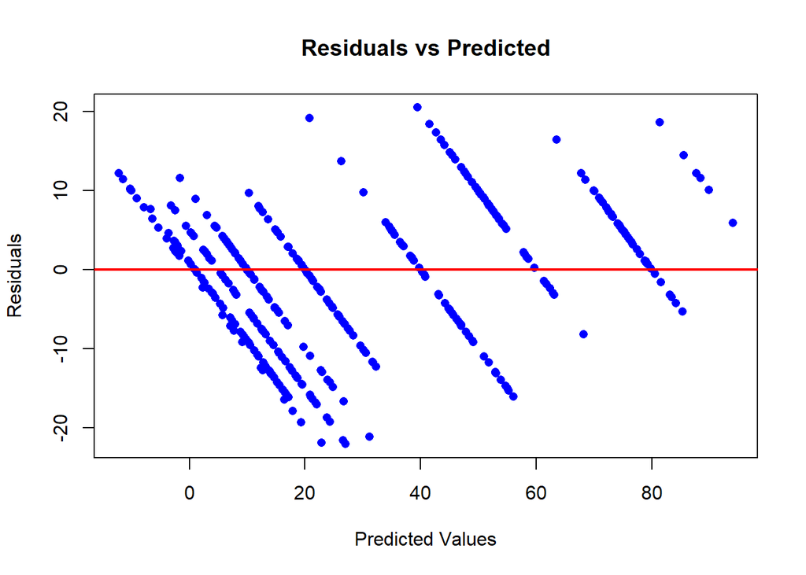

```r
# Check residuals

residuals <- observed - predictions

# Plot Residuals
plot(predictions, residuals,
     xlab = "Predicted Values",
     ylab = "Residuals",
     main = "Residuals vs Predicted",
     pch = 16, col = "blue")
abline(h = 0, col = "red", lwd = 2)
```

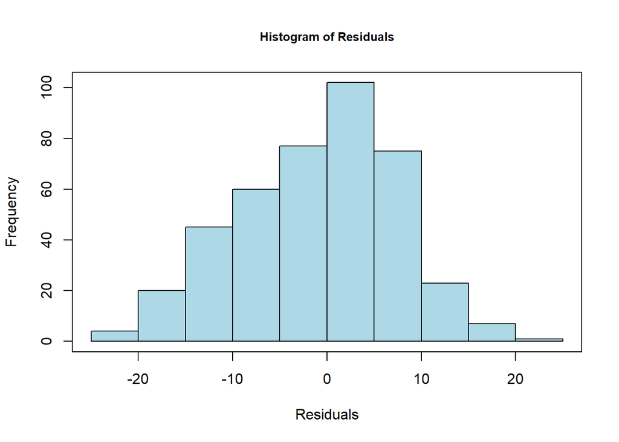

```r
hist(residuals,
     main = "Histogram of Residuals",
     xlab = "Residuals", cex.main = 0.8,
     col = "lightblue", border = "black"); box()
```

## Conclusion

- Boruta algorithm and PLS demonstrate good performance in predicting adulteration in ground coffee. The model achieves an RPD value of 3.4.